# Freshwater Creel Report Hoh winter steelhead 2023-24

2026-03-30

This report is intended to communicate preliminary results of freshwater salmon and steelhead roving creel surveys, which are implemented and managed through coordination with WDFW regional staff and the Freshwater Recreational Fisheries Monitoring team of the Statewide Salmon and Steelhead Management Unit.

Please note that the data provided has not yet undergone complete Quality Assurance/Quality Control (QA/QC) procedures and may be subject to revision.

# Setup code chunks

#### Report parameters

**Click to view report parameters**

```yaml
project_name: District 16
fishery_name: Hoh winter steelhead 2023-24
est_date_start: '2023-12-01'
est_date_end: '2024-03-31'
est_catch_groups:
  species: Steelhead
  life_stage: Adult
  fin_mark: UM
  fate: Released
study_design: Standard
boat_type_collapse: 'Yes'
fish_location_determines_type: 'No'
angler_type_kayak_pontoon: bank
person_count_type: group
period_pe: week
period_bss: day
days_wkend:
- Saturday
- Sunday
day_length_expansion: night closure
min_fishing_time: 0.5
bss_model_file_name: BSS_creel_model_02_2024-04-03.stan
model_used: Both models
data_grade: provisional
export: local
export_tables: both
enable_cache: yes
```

#### Load packages

```r
# Load packages
library("cli")
library("here")
library("yaml")
library("tidyverse")
library("glue")
library("patchwork")
library("gt")
library("parallel")
library("timeDate")
library("rstan")
library("posterior")
library("bayesplot")
library("digest")

# Load packages from source
# devtools::install_github("wdfw-fp/creelutils")
library(creelutils)
```

#### Selected catch groups

The following catch groups of fish were selected for generating catch estimates.

| # | Species | Life stage | Mark status | Fate |
| --- | --- | --- | --- | --- |
| 1 | Steelhead | Adult | UM | Released |

#### Fishery dates

```r
tibble(
  `Start date`= format(as.Date(params$est_date_start), "%m/%d/%Y"),
  `End date` = format(as.Date(params$est_date_end), "%m/%d/%Y")
) |>
  gt() |>
tab_header(
    title = "Start and end dates for creel survey data used in this report.") |>
  tab_options(
    heading.title.font.size = px(14),
    table.font.color = "black"
  )
```

Start and end dates for creel survey data used in this report.

| Start date | End date |
| --- | --- |
| 12/01/2023 | 03/31/2024 |

#### Script setup

```r
# Setup
# knitr options - MINIMAL initial setup (will be overridden by setup_analysis_structure)
knitr::opts_chunk$set(
  warning = FALSE,
  message = FALSE,
  cache = FALSE,          # Will be set based on params$enable_cache
  fig.width = 10,
  fig.height = 8
)

# Package settings
rstan_options(auto_write = TRUE)

# Global R settings
theme_set(theme_light()) #ggplot theme

# Create hash for cache invalidation when params change
param_hash <- digest::digest(params)

# Display cache status
if (params$enable_cache) {
  cli_alert_success("Cache is ENABLED - cached results will be reused when possible")
} else {
  cli_alert_warning("Cache is DISABLED - all chunks will be re-executed")
}

# Load functions (pre-package method)
walk(list.files(here("R_functions"), full.names = T), source)

# adjust day_length inputs
day_length_inputs <- list()
if(params$day_length_expansion == "manual"){
# Step #1: Select general strategy for [earliest] start and [latest] end time
    day_length_inputs$start_time<-c("manual") # enter either "sunrise" or "manual"
    day_length_inputs$end_time<-c("sunset")    # enter either "sunset"  or "manual"
  # Step #2A: If necessary, specify an offset (in hours) to the start and end times
    # (e.g., if legal fishing occurs 1 hr. prior to sunrise & sunset, enter 1
    # below for both); enter 0 if no offset needed
    day_length_inputs$start_adj<-c(1) # Specify an offset for the start time (in hours);
    day_length_inputs$end_adj<-c(1)   # Specify an offset for the end time (in hours);
  # Step #2B: If "manual" entered for "ui_start_time" or "ui_end_time", enter the
    # earliest start and/or latest end time for a creel survey event
    day_length_inputs$start_manual<-c("06:00:00") # Specify manual start time
    # (format "HH:MM:SS", e.g., 6 AM = "06:00:00")
    day_length_inputs$end_manual<-  c() # Specify manual end time (format "HH:MM:SS")
}

# Establish directory structure
## Define directory structure
path_components <- list(
  here("fishery_analyses"),
  here("fishery_analyses", params$project_name),
  here("fishery_analyses", params$project_name, params$fishery_name)
)

## Create directories as needed
path_components |>
  walk(~ if (!dir.exists(.x)) {
    dir.create(.x, recursive = TRUE)
    message(glue("Folder(s) created: \n{.x}"))
  })

# Generate analyis metadata
## Get current file path for analysis folder detection
current_file <- tryCatch({
  # CASE 1: Knitting
  if (!is.null(knitr::current_input())) {
    file.path(getwd(), knitr::current_input())
  # CASE 2: Interactive RStudio
  } else if (requireNamespace("rstudioapi", quietly = TRUE) && rstudioapi::isAvailable()) {
    rstudioapi::getSourceEditorContext()$path
  } else {
    NULL
  }
}, error = function(e) NULL)

## Generate or load analysis_lut (uses existing function as-is)
generate_analysis_lut(params, current_file_path = current_file)

# Display analysis metadata
cli_alert_info("Analysis ID: {.val {analysis_lut$analysis_id}}")
cli_alert_info("Analysis Folder: {.val {analysis_lut$analysis_folder}}")
cli_alert_info("Identifier: {.val {analysis_lut$identifier}}")

# Create analysis folder structure and configure knitr
# THIS will set the cache.path and fig.path correctly
analysis_structure <- setup_analysis_structure(params, analysis_lut)

# Extract paths for use in subsequent chunks
analysis_folder_path <- analysis_structure$analysis_folder_path
outputs_folders <- analysis_structure$outputs_folders
cache_path <- analysis_structure$cache_path

# Copy current Rmd file to analysis folder and save metadata files
save_analysis_metadata(
  params = params,
  analysis_lut = analysis_lut,
  analysis_folder_path = analysis_folder_path,
  current_file_path = current_file
)
```

#### Load helper functions to save plots/tables

```r
# Note: This chunk always has cache=FALSE to ensure functions are loaded fresh
# Helper functions loaded in global environment to make save functions work with knitr

# Helper function to save plots to the figures folder
save_plot <- function(plot_obj, filename, width = 10, height = 8, ...) {
  if (!exists("outputs_folders")) {
    stop("outputs_folders not defined. Run setup chunk first.")
  }

  filepath <- file.path(outputs_folders$figures, filename)

  # Save as PNG
  ggsave(
    filename = filepath,
    plot = plot_obj,
    width = width,
    height = height,
    dpi = 300,
    ...
  )

  # Also save as PDF
  pdf_path <- sub("\\.png$", ".pdf", filepath)
  ggsave(
    filename = pdf_path,
    plot = plot_obj,
    width = width,
    height = height,
    ...
  )

  cli_alert_success("Plot saved: {.file {basename(filepath)}}")

  return(invisible(plot_obj))
}

# Helper function to save gt tables to the figures folder (HTML ONLY - no Chrome needed)
save_gt_table <- function(gt_obj, filename) {
  if (!exists("outputs_folders")) {
    stop("outputs_folders not defined. Run setup chunk first.")
  }

  # Remove extension if provided
  filename_base <- tools::file_path_sans_ext(filename)

  # Save as HTML only (no Chrome/PNG export)
  html_path <- file.path(outputs_folders$figures, paste0(filename_base, ".html"))
  gt::gtsave(gt_obj, filename = html_path)

  cli_alert_success("Table saved as HTML: {.file {basename(html_path)}}")

  return(invisible(gt_obj))
}
```

# Fetch and review data

## Download data

```r
dwg <- creelutils::fetch_dwg(params$fishery_name)

# Save raw data
saveRDS(dwg, file.path(outputs_folders$inputs, "dwg_raw.rds"))

dwg$days <- prep_days(
  params = params,
  date_begin = params$est_date_start,
  date_end = params$est_date_end,
  weekends = params$days_wkend,
  # holidays = read_lines(paste(here(), "input_files/dates_holidays_2015_2030.txt", sep = "/")),
  lat = mean(dwg$ll$centroid_lat), #can/should consider smarter options
  long = mean(dwg$ll$centroid_lon),#can/should consider smarter options
  period_pe = params$period_pe,
  sections = unique(dwg$interview$section_num),
  closures = dwg$closures,
  day_length = params$day_length_expansion,
  day_length_inputs = day_length_inputs
  )

# Save processed days
saveRDS(dwg$days, file.path(outputs_folders$inputs, "dwg_days.rds"))
```

## River sections

Description of the spatial units of the creel survey. Each is listed by section number with a description of their downstream and upstream extent within the river system.

```r
# Summary table of water_body, section_nums, and locations for a given fishery
dwg$effort |>
  filter(location_type == "Section") |>
  distinct(water_body, section_num, location) |>
  arrange(section_num) |>
  select(`Water Body` = water_body, `Section Number` = section_num, `Location description` = location) |>
  gt()
```

| Water Body | Section Number | Location description |
| --- | --- | --- |
| Hoh River | 1 | Lower - ONP coastal boundary upstream to Oxbow Campground |
| Hoh River | 2 | Middle - Oxbow Campground upstream to Morgan's Crossing |
| Hoh River | 3 | Upper - Morgan's Crossing upstream to ONP boundary |

## Review days and sampling periods

```r
# Summary table of all dates (not just surveyed dates) for a given fishery & whether each section_num was open or closed
# dwg$days |>
#   mutate(across(starts_with("open_"), ~if_else(., "open","closed"))) |>
#   rename_with(.cols = starts_with("open_"), .fn = ~str_remove_all(., "open_")) |>
#   gt::gt() |>
#   gt::data_color(
#     columns = contains("section_"),
#     fn = scales::col_factor(
#       palette = c("#C3C7C3", "#78B574"),
#       domain = c("closed","open")
#     )
#   )
```

## Summary table of effort counts

```r
dwg$effort |>
  filter(between(event_date, as.Date(params$est_date_start), as.Date(params$est_date_end))) |>
  distinct(section_num, location, event_date, tie_in_indicator, count_sequence) |>
  count(section_num, location, tie_in_indicator) |>
  mutate(
    tie_in_indicator = case_when(
      tie_in_indicator == 1 ~ "census",
      tie_in_indicator == 0 ~ "index"
      ),
    section_label = paste("Section", section_num),
    location = case_when(
    tie_in_indicator == "census" ~ paste(section_label, "-", location),
    TRUE ~ location
  )) |>
  arrange(section_num, tie_in_indicator, location) |>
  select(-section_label) |>
  gt() |>
tab_header(
    title = "The sum of distinct effort surveys by section number, location, and survey type. Survey type options were index and census effort counts. Census surveys were direct counts of anglers. Index surveys were indirect counts, where objects assumed to represent anglers (e.g., vehicles and boat trailers) are counted at a standardized set of access locations in the fishery area.") |>
  tab_options(
    heading.title.font.size = px(14),
    table.font.color = "black"
  ) |>
  cols_hide(columns = "section_num") |>   # hide the group column itself
  tab_style(
    style = list(cell_fill("grey90"), cell_text(weight = "bold", color = "black")),
    locations = cells_body(rows = tie_in_indicator == "census")
  ) |>
  cols_label(
    location = "Location",
    tie_in_indicator = "Survey Type",
    n = "Effort Counts"
  )
```

The sum of distinct effort surveys by section number, location, and survey type. Survey type options were index and census effort counts. Census surveys were direct counts of anglers. Index surveys were indirect counts, where objects assumed to represent anglers (e.g., vehicles and boat trailers) are counted at a standardized set of access locations in the fishery area.

| Location | Survey Type | Effort Counts |
| --- | --- | --- |
| Section 1 - Lower - ONP coastal boundary upstream to Oxbow Campground | census | 5 |
| Allen's Bar | index | 123 |
| Barlow's | index | 126 |
| Cassel Bar | index | 126 |
| Cottonwood Campground | index | 118 |
| G & L Shake's | index | 124 |
| Goodman Mainline | index | 125 |
| Highway 101 bridge | index | 109 |
| Hoh River Resort | index | 126 |
| Nolan Creek | index | 122 |
| ONP coastal boundary trailhead | index | 125 |
| Rip-rap repair area | index | 122 |
| Section 2 - Middle - Oxbow Campground upstream to Morgan's Crossing | census | 5 |
| Minnie Peterson | index | 124 |
| Oxbow Campground | index | 125 |
| Rock Creek | index | 123 |
| Willoughby Creek | index | 124 |
| Winfield Creek | index | 120 |
| Section 3 - Upper - Morgan's Crossing upstream to ONP boundary | census | 5 |
| Canyon Creek | index | 125 |
| Morgan's Crossing | index | 125 |
| ONP boundary boat launch | index | 124 |
| Pole Creek Bar | index | 124 |
| Spruce Creek | index | 124 |
| Upper Spruce Canyon | index | 124 |

## Summary table of angler interviews

```r
# Total number of angler group interviews by section_num and fishing_location
dwg$interview |>
  filter(between(event_date, as.Date(params$est_date_start), as.Date(params$est_date_end))) |>
  count(section_num, fishing_location) |>
  arrange(section_num) |>
  gt() |>
  tab_header(
    title = "The sum of the number of angler interviews completed by surevey staff grouped by river section."
  ) |>
  tab_options(
    heading.title.font.size = px(14),
    table.font.color = "black"
  ) |>
  grand_summary_rows(
    fns = "sum",
    columns = "n",
    missing_text = ""
  ) |>
tab_style(
    style = cell_text(color = "black"),
    locations = cells_title()
  ) |>
  cols_label(
    section_num = "Section number",
    fishing_location = "Desciption",
    n = "Count"
  )
```

The sum of the number of angler interviews completed by surevey staff grouped by river section.

|  | Section number | Desciption | Count |
| --- | --- | --- | --- |
|  | 1 | Lower - ONP coastal boundary upstream to Oxbow Campground | 357 |
|  | 2 | Middle - Oxbow Campground upstream to Morgan's Crossing | 253 |
|  | 3 | Upper - Morgan's Crossing upstream to ONP boundary | 149 |
| sum |  |  | 759 |

## Summary of reported catch

```r
# Total number of "encounters" for each unique catch_group recorded during angler group interviews
dwg$catch |>
  left_join(dwg$interview, by = "interview_id") |>
  filter(between(event_date, as.Date(params$est_date_start), as.Date(params$est_date_end))) |>
  group_by(catch_group) |>
  summarise(fish_count = sum(fish_count), .groups = "drop") |>
gt() |>
  tab_header(
    title = "The sum of reported catches of all species reported in interviews, Catch group was defined as individual combinations of species, life stage, fin mark, and fate."
  ) |>
  tab_options(
    heading.title.font.size = px(14),
    table.font.color = "black"
  ) |>
tab_style(
    style = cell_text(color = "black"), # Note: cells_caption(), not cells_source_notes()
    locations = cells_title()
  ) |>
  cols_label(
    catch_group = "Catch group",
    fish_count = "Count"
  )
```

The sum of reported catches of all species reported in interviews, Catch group was defined as individual combinations of species, life stage, fin mark, and fate.

| Catch group | Count |
| --- | --- |
| Bull Trout_NA_NA_Released | 53 |
| Coastal Cutthroat_NA_NA_Released | 6 |
| Dolly Varden_NA_NA_Released | 6 |
| Rainbow Trout_NA_NA_Released | 2 |
| Steelhead_Adult_AD_Released | 1 |
| Steelhead_Adult_UM_Released | 710 |
| Steelhead_Adult_UNK_Released | 1 |
| Steelhead_Jack_UM_Released | 1 |
| Steelhead_Smolt_UM_Released | 6 |
| Steelhead_Smolt_UNK_Released | 6 |
| Trout - Unspecified_NA_NA_Released | 4 |
| Whitefish_Adult_UM_Released | 3 |
| Whitefish_Legal sturgeon_NA_Released | 1 |
| Whitefish_NA_NA_Released | 220 |

## Manual data edits (if needed)

```r
# If needed, manually edit/filter the creel data imported from dwg; be sure to include an explanation of each edit
```

## Shared data aggregation

```r
# Create blank list that will be used to attach the following three datasets
  dwg_summ <- list() #intermediate objects wrangled from creel list elements

# 1.) Interview data summarization
  # 1.1 - Summarize fishing time
  interview_fishing_time <-
    prep_dwg_interview_fishing_time(
      params = params,
      dwg_interview = dwg$interview |> filter(between(event_date, as.Date(params$est_date_start), as.Date(params$est_date_end))),
      #person_count_type = params$person_count_type,
      min_fishing_time = params$min_fishing_time,
      study_design = params$study_design
    )

  # 1.2 - Summarize angler types (angler_final based on arguments)
  interview_plus_angler_types <-
    prep_dwg_interview_angler_types(
      params = params,
      interview_fishing_time = interview_fishing_time,
      study_design = params$study_design,
      boat_type_collapse = params$boat_type_collapse,
      fish_location_determines_type = params$fish_location_determines_type,
      angler_type_kayak_pontoon = params$angler_type_kayak_pontoon
    )

    # 1.2.1 - Preview angler_final designations
      interview_plus_angler_types |> select(interview_id, angler_type, boat_used, boat_type, fish_from_boat, angler_final) |> group_by(boat_used, fish_from_boat, boat_type) |> count(angler_final)

  # 1.3 - Summarize catch (for catch groups of interest)
  interview_plus_catch <-
    prep_dwg_interview_catch(
      params = params,
      interview_plus_angler_types = interview_plus_angler_types,
      study_design = params$study_design,
      dwg_catch = dwg$catch,
      est_catch_groups = params$est_catch_groups
    )

  # 1.4 - Attach the final formatted interview data set to "dwg_summ"
    dwg_summ$interview <-interview_plus_catch

# 2.) Effort index data summarization
  # 2.1 - Aggregate index effort counts over locations within count_seq & section; count_types are converted to angler_final based on arguments
      effort_index_summ <-
        prep_dwg_effort_index(
          params = params,
          eff = dwg$effort |> filter(between(event_date, as.Date(params$est_date_start), as.Date(params$est_date_end))),
          study_design = params$study_design,
          boat_type_collapse = params$boat_type_collapse,
          fish_location_determines_type = params$fish_location_determines_type,
          angler_type_kayak_pontoon = params$angler_type_kayak_pontoon
        )

    # 2.1.1 - Summary of count_types and their corresponding "angler_final" designation
      effort_index_summ$index_angler_groups |> group_by(count_type) |> distinct(angler_final)

    # 2.1.2 - QAQC - are there any census effort count groups that "failed"
      # NOTE: fails get filtered out from "effort_index_summ$index_angler_final so make sure this is correct
      effort_index_summ$index_angler_groups |> distinct(angler_final)

    # 2.2 - Attach the final formatted effort index data set to "dwg_summ"
      dwg_summ$effort_index <- effort_index_summ$index_angler_final

# 3.) Effort census data summarization
  # 3.1 - Aggregate census (tie in) effort counts, associating to closest-in-time index count
    ##NOTE: a warning message will appear indicating "...an unexpected many-to-many relationship..." if multiple effort census counts were completed in the same section and day; this message can be ignored as the data wrangling works as intended despite this warning
    effort_census_summ <-
      prep_dwg_effort_census(
        params = params,
        eff = dwg$effort |> filter(between(event_date, as.Date(params$est_date_start), as.Date(params$est_date_end))),
        study_design = params$study_design,
        boat_type_collapse = params$boat_type_collapse,
        fish_location_determines_type = params$fish_location_determines_type,
        angler_type_kayak_pontoon = params$angler_type_kayak_pontoon
      )

    # 3.1.1 - QAQC - are there any census effort count groups that "failed"
      # NOTE: fails get filtered out from "effort_index_summ$index_angler_final so make sure this is correct
    effort_census_summ$census_angler_groups |> filter(angler_final == "fail")

    # 3.2 - Attach the final formatted effort census data set to "dwg_summ"
    dwg_summ$effort_census <- effort_census_summ$census_angler_final

# 4.) Generate summary table of "p_census"
    (dwg_summ$census_expan <-
      prep_dwg_census_expan(
        params = params,
        eff = dwg$effort,
        days = dwg$days
      ))

# Save summarized data
saveRDS(dwg_summ, file.path(outputs_folders$inputs, "dwg_summ.rds"))
```

## Plot of index effort counts

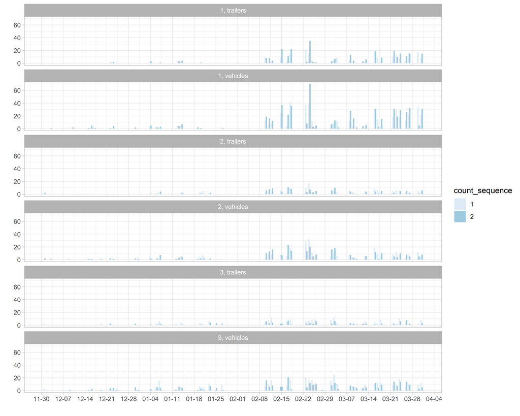

Index effort counts for each count sequence on surveyed days within the monitoring period. Index counts represent the sum of counts completed at each sampling site during a drive around effort count.

```r
# plot of index effort counts faceted by section and count_type per count sequence and day

# rename to items actually counted
summarised_index_counts <- dwg_summ$effort_index |>
  mutate(
    angler_final = case_when(
      angler_final == "boat" ~ "trailers",
      angler_final == "total" ~ "vehicles",
      TRUE ~ angler_final  # keeps any other values unchanged
    )
  )

plot_inputs_pe_index_effort_counts(
  params = params,
  effort_index = summarised_index_counts,
  outputs_folders = outputs_folders)
```

# Effort and catch estimation

This section contains preliminary estimates of angler effort and catch during the Hoh winter steelhead 2023-24 fishery. Settings for the Bayesian state space creel model are contained in folded code, select “show” to view the settings used for this report, including priors used for model parameters and sampler settings.

## PE estimation

### Create PE input object

```r
inputs_pe <- list()

# Calculate total days the fishery was open per strata (strata = period, day_type, and section_num)
  (inputs_pe$days_total <-
    prep_inputs_pe_days_total(
      days = dwg$days
    ))

# Calculate anglers per count_type object by angler_final
  #NOTE: these estimates are used to expand index counts of objects to number of angler; e.g., trailer counts to boat anglers)
  #NOTE: these estimate are derived using interview data and calculated as a single, season-long, weighted average
  (inputs_pe$interview_ang_per_object <-
    prep_inputs_pe_int_ang_per_object(
      dwg_summarized = dwg_summ,
      study_design = params$study_design
    ))

# Calculate tie-in (aka census) count expansion factor by section & angler_final
  #NOTE: these estimates are used to spatially expand/bias correct angler effort count data collected during index counts
  #NOTE: these estimates are derived using paired census and index counts and calculated as a single, season-long, weighted average
  (inputs_pe$paired_census_index_counts <-
    prep_inputs_pe_paired_census_index_counts_aggregate(
      days = dwg$days,
      dwg_summarized = dwg_summ,
      interview_ang_per_object = inputs_pe$interview_ang_per_object,
      census_expan = dwg_summ$census_expan,
      study_design = params$study_design
    ))

# Calculate census-corrected angler effort (mean angler hours) by event_date, angler_type, and section_num
  (inputs_pe$ang_hrs_daily_mean <-
    prep_inputs_pe_ang_hrs_aggregate(
      days = dwg$days,
      dwg_summarized = dwg_summ,
      interview_ang_per_object = inputs_pe$interview_ang_per_object,
      paired_census_index_counts = inputs_pe$paired_census_index_counts,
      study_design = params$study_design
    ))

# Calculate CPUE and catch_estimates by event_date, angler_type, section_num, and est_cg (aka catch group of interest)
  (inputs_pe$daily_cpue_catch_est <-
    prep_inputs_pe_daily_cpue_catch_est(
      days = dwg$days,
      dwg_summarized = dwg_summ,
      angler_hours_daily_mean = inputs_pe$ang_hrs_daily_mean
    ))

# summary - creel surveys dates by section where estimated total effort for a particular "angler_final" grouping was >0  group but no interviews were obtained
  inputs_pe$daily_cpue_catch_est |> filter(is.na(est_cg), angler_hours_daily_mean>0)

# Calculate the degree of freedom used to derived estimates of uncertainty
  #NOTE: not sure these calculation are correct (e.g., WRONG/MISSING STRATA:  dplyr::group_by(section_num, angler_final))
  inputs_pe$df <-
    prep_inputs_pe_df(
      angler_hours_daily_mean = inputs_pe$ang_hrs_daily_mean
    )

# Save PE inputs
saveRDS(inputs_pe, file.path(outputs_folders$inputs, "inputs_pe.rds"))
```

### Paired census and index angler effort counts

```r
# table view of census / index surveys and resulting bias term ratio
inputs_pe$paired_census_index_counts |>
  select(section_num, angler_final, count_census, count_index, TI_expan_final) |>
  gt() |>
tab_header(
    title = "The season-long sum of paired census and index angler effort counts and corresponding bias-term ratio (TI_expan_final), indicating the magnitude and direction (postive or negative) of bias in index counts relative to census counts."
  ) |>
  tab_options(
    heading.title.font.size = px(14),
    table.font.color = "black"
  ) |>
  fmt_number(count_index, decimals = 0) |>
  fmt_number(TI_expan_final, decimals = 2)
```

[output not shown]

```r
plot_inputs_pe_census_vs_index(census_TI_expan = inputs_pe$paired_census_index_counts) +
 theme(plot.caption = element_text(size = 10, hjust = 0))
```

[output not shown]

### Generate PE estimates

```r
estimates_pe <- list()

estimates_pe$effort <-
  est_pe_effort(
    params = params,
    dwg = dwg,
    days = dwg$days,
    pe_inputs_list = inputs_pe
  )

estimates_pe$catch <-
  est_pe_catch(
    params = params,
    dwg = dwg,
    days = dwg$days,
    pe_inputs_list = inputs_pe
  )

# Save PE estimates
saveRDS(estimates_pe, file.path(outputs_folders$outputs, "estimates_pe.rds"))
```

### Effort estimates

```r
# effort by section_num
estimates_pe$effort |>
  group_by(section_num, angler_final) |>
  summarise(
    E_sum = round(sum(est, na.rm=T), 0),
    .groups = "drop"
  ) |>
  pivot_wider(names_from = section_num, values_from = E_sum) |>
  gt(caption = paste("Estimated effort (angler hours) by fishing section from", params$est_date_start, "to", params$est_date_end)) |>
  tab_options(
    heading.title.font.size = px(14),
    table.font.color = "black"
  )
```

Estimated effort (angler hours) by fishing section from 2023-12-01 to 2024-03-31

| angler_final | 1 | 2 | 3 |
| --- | --- | --- | --- |
| bank | 2797 | 1705 | 2326 |
| boat | 15087 | 7787 | 8381 |

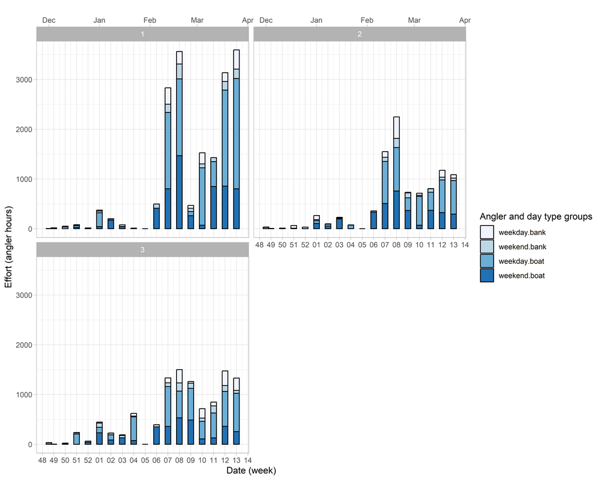

Estimated effort (angler-hours) grouped by time strata, section and angler type (angler_final).

```r
# barplot of effort estimates by time stratum, section, and angler type
plot_est_pe_effort(
  estimates_pe_effort = estimates_pe$effort,
  period_pe = params$period_pe,
  outputs_folders = outputs_folders,
  filename = "pe_effort_estimates_")
```

### Catch rate (CPUE) estimates

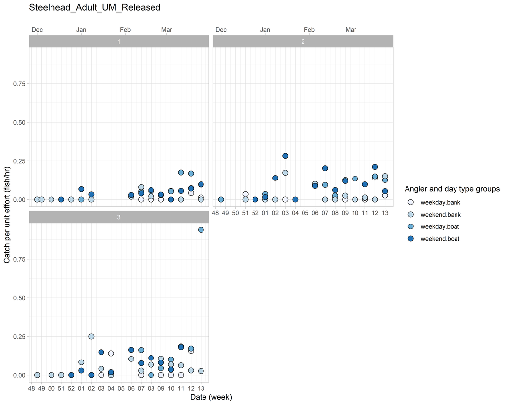

```r
# plot of catch rate estimates by catch group, time stratum, section, and angler type
unique(na.omit(inputs_pe$daily_cpue_catch_est$est_cg)) |>
set_names() |>
map(
  ~plot_inputs_pe_cpue_period(
    days = dwg$days,
    dwg_summarized = dwg_summ,
    daily_cpue_catch_est = inputs_pe$daily_cpue_catch_est,
    est_catch_group = .x,
    period_pe = params$period_pe,
    outputs_folders = outputs_folders,
    filename = paste0("pe_cpue_estimates_", stringr::str_replace_all(.x, "[^[:alnum:]]", "_")) #safe name when using | operator in catch group
  )
)
```

### Catch estimates

```r
  estimates_pe$catch |>
          group_by(est_cg, section_num) |>
          summarise(
            C_sum = sum(est),
            .groups = "drop"
          ) |>
        pivot_longer(
          cols = -c(est_cg, section_num),
          names_to = "estimate",
          values_to = "PE"
        ) |>
    select(est_cg, section_num, estimate, PE, everything()) |>
  gt(groupname_col = "est_cg", caption = "Total estimates of catch during the monitoring period for each fish catch group.") |>
  fmt_number(-c(estimate, est_cg, section_num), decimals = 1) |>
  tab_style(
    style = cell_fill(), locations = cells_body(columns = "PE")
  ) |>
  tab_style(
    style = cell_fill(), locations = cells_body(columns = "PE")
  )
```

Total estimates of catch during the monitoring period for each fish catch group.

| section_num | estimate | PE |
| --- | --- | --- |
| Steelhead_Adult_UM_Released |  |  |
| 1 | C_sum | 1,252.1 |
| 2 | C_sum | 941.4 |
| 3 | C_sum | 989.7 |

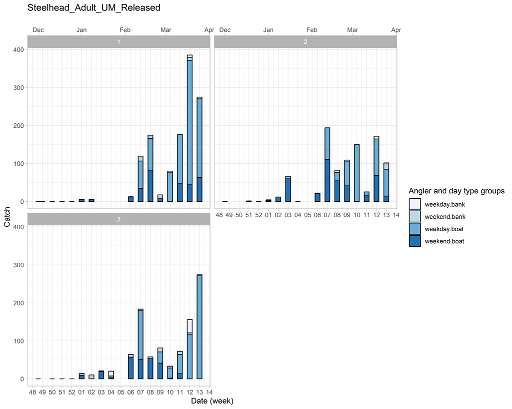

```r
# barplot of catch estimates by catch group, time stratum, section, and angler type
unique(na.omit(estimates_pe$catch$est_cg)) |>
set_names() |>
map(
  ~plot_est_pe_catch(
    estimates_pe_catch = estimates_pe$catch,
    est_catch_group = .x,
    period_pe = params$period_pe,
    outputs_folders = outputs_folders,
    filename = paste0("pe_catch_estimates_", stringr::str_replace_all(.x, "[^[:alnum:]]", "_"))) #safe name when using | operator in catch group
)
```

## BSS estimation

```r
dwg_summ$interview |> group_by(est_cg) |> summarise(sum(fish_count)/sum(fishing_time_total))
```

```
## # A tibble: 1 × 2
##   est_cg                      `sum(fish_count)/sum(fishing_time_total)`
##   <chr>                                                           <dbl>
## 1 Steelhead_Adult_UM_Released                                    0.0725
```

### Create BSS input object

```r
#either a single element list for a single catch_group
#or a list of bss-input-lists, one for each catch_group
inputs_bss <-
  unique(na.omit(dwg_summ$interview$est_cg)) |>
  set_names() |>
  map(
    ~prep_inputs_bss(
      est_catch_group = .x,
      period = params$period_bss,
      days = dwg$days,
      dwg_summarized = dwg_summ,
      census_expan = dwg_summ$census_expan,
      study_design = params$study_design,
      priors = c(
        value_cauchyDF_sigma_eps_C = 0.5,
        value_cauchyDF_sigma_eps_E = 0.5,
        value_cauchyDF_sigma_r_E = 0.5,
        value_cauchyDF_sigma_r_C = 0.5,
        value_cauchyDF_sigma_mu_C = 0.5,
        value_cauchyDF_sigma_mu_E = 0.5,
        value_normal_sigma_omega_C_0 = 1,
        value_normal_sigma_omega_E_0 = 3,
        value_lognormal_sigma_b = 1,
        value_normal_sigma_B1 = 5,
        value_normal_mu_mu_C = log(0.07),
        value_normal_sigma_mu_C = 1.5,
        value_normal_mu_mu_E = log(5),
        value_normal_sigma_mu_E = 2,
        value_betashape_phi_E_scaled = 1,
        value_betashape_phi_C_scaled = 1
    )
    )
  )

# Save BSS inputs
saveRDS(inputs_bss, file.path(outputs_folders$inputs, "inputs_bss.rds"))
```

### Generate BSS estimates

```r
#should work for either single or multiple catch_group

# ---- CONFIGURATION ----
# Set to TRUE to save draw objects (WARNING: large file sizes)
save_draws <- TRUE  # Change to TRUE if you want to save draws
# ----------------------

# create empty lists for outputs
estimates_bss <- list()
diagnostics_bss <- list()
convergence_tables <- list()
if (save_draws) {
  draws_bss <- list()
  draws_array <- list()
}

for(ecg in names(inputs_bss)) {
  # fit the model to generate estimates
  ecg_fit <-
    fit_bss(
      bss_inputs_list = inputs_bss[[ecg]],
      n_chain = 4,
      n_cores = 4,
      n_iter = 2000,
      n_warmup = 1000,
      n_thin = 1,
      adapt_delta = 0.8,
      max_treedepth = 12,
      init = "0"
    )

  ## extract and summarize estimates and model fit statistics
  ecg_keep <- list()
  ecg_keep$overview <- get_bss_overview(bss_fit = ecg_fit, ecg = ecg)
  ecg_keep$cpue_daily <- get_bss_cpue_daily(bss_fit = ecg_fit, ecg = ecg, dwg = dwg)
  ecg_keep$catch_daily <- get_bss_catch_daily(bss_fit = ecg_fit, ecg = ecg, dwg = dwg)
  ecg_keep$effort_daily <- get_bss_effort_daily(bss_fit = ecg_fit, ecg = ecg, dwg = dwg)

  # Always extract draws for use in diagnostics and plots
  ecg_keep$draws <- extract(ecg_fit)

  # ---- NEW: Prepare season results and create density plot ----
  ecg_keep$season_results <- get_bss_season_results(ecg_keep$draws, ecg)
  ecg_keep$density_plot <- create_bss_density_plot(ecg_keep$season_results, ecg)

  ecg_keep$summary <- summary(ecg_fit)$summary
  ecg_keep$ppc_values <- calculate_ppc_pvalues(
    bss_fit = ecg_fit,
    inputs_bss = inputs_bss,
    ecg = ecg)

  invisible(ecg_keep$ppc_results <- generate_ppc_plots(
    bss_fit = ecg_fit,
    inputs_bss = inputs_bss,
    ecg = ecg,
    dwg = dwg,
    params = params))

  ## store estimates and model fit
  estimates_bss[[ecg]] <- ecg_keep

  # ---- START: Process draws and generate convergence diagnostics ----
  # Extract draws from fit object
  draws_array_temp <- posterior::as_draws_array(ecg_fit)
  draws_df_full <- posterior::as_draws_df(draws_array_temp)

  ## subset parameters
  params_keep <- c(
    "mu_E", "mu_C",
    "lambda_E_S", "lambda_C_S",
    "omega_E", "omega_C",
    "r_E", "r_C",
    "sigma_eps_E", "sigma_eps_C",
    "Lcorr_E", "Lcorr_C",
    "phi_E_scaled", "phi_C_scaled",
    "sigma_r_E", "sigma_r_C",
    "p_I",
    "mu_mu_E", "sigma_mu_E", "eps_mu_E",
    "mu_mu_C", "sigma_mu_C", "eps_mu_C"
  )

  ## subset and format
  draws_df <- posterior::subset_draws(draws_df_full, variable = params_keep) |>
    relocate(c(".draw", ".iteration", ".chain"))

  ## calculate summary stats
  summary_df <- posterior::summarize_draws(
    draws_df,
    measures = list(mean, sd, mad, posterior::quantile2, rhat, ess_bulk, ess_tail)
  )

  colnames(summary_df) <- c("variable", "mean", "sd", "mad", "q5", "q95", "rhat", "ess_bulk", "ess_tail")

  # Save draws if requested
  if (save_draws) {
    draws_bss[[ecg]] <- list(
      draws_df = draws_df,
      summary_df = summary_df
    )
    draws_array[[ecg]] <- draws_array_temp
    cli::cli_alert_info("Draws saved for catch group: {ecg}")
  }

  # Create and save convergence diagnostics
  convergence_table <- create_convergence_table(summary_df, ecg)
  convergence_tables[[ecg]] <- convergence_table

  # Save convergence diagnostics (creates gt table and saves to figures folder)
  save_convergence_diagnostics(convergence_table, ecg, outputs_folders)

  # ---- UPDATED: Clean up memory - conditionally remove draws ----
  if (!save_draws) {
    # Remove draws from estimates_bss to save memory
    estimates_bss[[ecg]]$draws <- NULL
    estimates_bss[[ecg]]$season_results <- NULL  # Also remove season results as they contain draw data

    # Remove temporary draw objects
    rm(draws_array_temp, draws_df_full, draws_df)
    gc()  # Force garbage collection
    cli::cli_alert_info("Draws cleaned up for catch group: {ecg}")
  } else {
    # Keep draws but still remove the full unsubsetted version
    rm(draws_df_full)
    gc()
    cli::cli_alert_info("Draws retained for catch group: {ecg}")
  }
  # ---- END: Process draws and generate convergence diagnostics ----

  cli::cli_alert_success("Model run completed for catch group: {ecg}\n")

  # extract and generate model diagnostics
  diagnostics_keep <- list()
  diagnostics_keep$bss_runtime_cg <- creelutils::get_bss_runtime(ecg_fit)
  cat("\n")
  cli::cli_rule()

  diagnostics_keep$bss_hmc_diagnostic_cg <- capture.output(creelutils::get_hmc_diagnostics(stan_fit = ecg_fit))
  cat(diagnostics_keep$bss_hmc_diagnostic_cg, sep = "\n")
  cat("\n")
  cli::cli_rule()

  diagnostics_keep$bss_settings_cg <- get_bss_settings(ecg, ecg_fit, inputs_bss, print = TRUE) |> capture.output()
  cat(diagnostics_keep$bss_settings_cg, sep = "\n")

  # trace plots
  invisible(diagnostics_keep$traceplots <- mcmc_trace(
    ecg_fit,
    pars = c(
      "C_sum", "E_sum", "phi_C_scaled", "phi_E_scaled",
      "sigma_r_C", "sigma_r_E", "sigma_eps_C", "sigma_eps_E",
      "sigma_mu_C", "sigma_mu_E", "phi_C", "phi_E",
      "r_C", "r_E", "B1", "lp__"
    ),
    np = nuts_params(ecg_fit)
  ) +
    labs(
      x = "Post-warmup iteration",
      title = paste("Trace plots for catch group:", ecg)
    ) +
    theme(axis.text.x = element_text(angle = 45, hjust = 1)))

  safe_name <- stringr::str_replace_all(ecg, "[^[:alnum:]]", "_")

  # Save the traceplot
  save_plot(
    diagnostics_keep$traceplots,
    paste0("traceplot_", safe_name, ".png"),
    width = 12,
    height = 10
  )

  diagnostics_bss[[ecg]] <- diagnostics_keep

  # Additional memory cleanup - remove fit object after extracting what we need
  rm(ecg_fit)
  gc()
}

# Save BSS estimates and diagnostics
saveRDS(estimates_bss, file.path(outputs_folders$outputs, "estimates_bss.rds"))
saveRDS(diagnostics_bss, file.path(outputs_folders$outputs, "diagnostics_bss.rds"))
saveRDS(convergence_tables, file.path(outputs_folders$outputs, "convergence_tables.rds"))

# ---- NEW: Combine and save density plots ----
density_plots <- map(estimates_bss, ~.$density_plot)
combined_density_plot <- save_bss_density_plots(density_plots, outputs_folders)
cli::cli_alert_success("Density plots saved")

# Conditionally save draws if requested
if (save_draws) {
  saveRDS(draws_bss, file.path(outputs_folders$outputs, "draws_bss.rds"))
  saveRDS(draws_array, file.path(outputs_folders$outputs, "draws_array.rds"))
  cli::cli_alert_success("Draws saved to outputs folder")
} else {
  cli::cli_alert_info("Draws not saved (save_draws = FALSE)")
}
```

### BSS convergence diagnostics

#### Summary tables with converge statistics

```r
# Display convergence diagnostics tables in document
for (ecg in names(convergence_tables)) {
  tbl <- convergence_tables[[ecg]] |>
    dplyr::slice_head(n = 15) |>
    dplyr::select(-rhat) |>
    dplyr::relocate(rhat_display, .after = variable) |>
    gt::gt() |>
    gt::cols_label(
      variable = "Parameter",
      rhat_display = "Rhat",
      ess_bulk = "ESS_bulk",
      ess_tail = "ESS_tail"
    ) |>
    gt::tab_header(
      title = glue::glue("Catch Group: {ecg}"),
      subtitle = "Parameters shown meet at least one criteria: Rhat >= 1.09 or ESS < 100"
    ) |>
    gt::tab_style(
      style = gt::cell_text(align = "left"),
      locations = gt::cells_title(groups = "subtitle")
    ) |>
    gt::tab_footnote(
      footnote = "Filtered to 15 rows, sorted by descending Rhat",
      locations = gt::cells_column_labels(columns = rhat_display)
    )
  # Emit raw HTML so knitr renders the widget
  cat(gt::as_raw_html(tbl))
}
```

Catch Group: Steelhead_Adult_UM_Released

Parameters shown meet at least one criteria: Rhat >= 1.09 or ESS < 100

| Parameter | Rhat<sup>1</sup> | ESS_bulk | ESS_tail | Mean | SD | MAD | 5% | 95% |
| --- | --- | --- | --- | --- | --- | --- | --- | --- |

<sup>1</sup> Filtered to 15 rows, sorted by descending Rhat

#### Trace plots

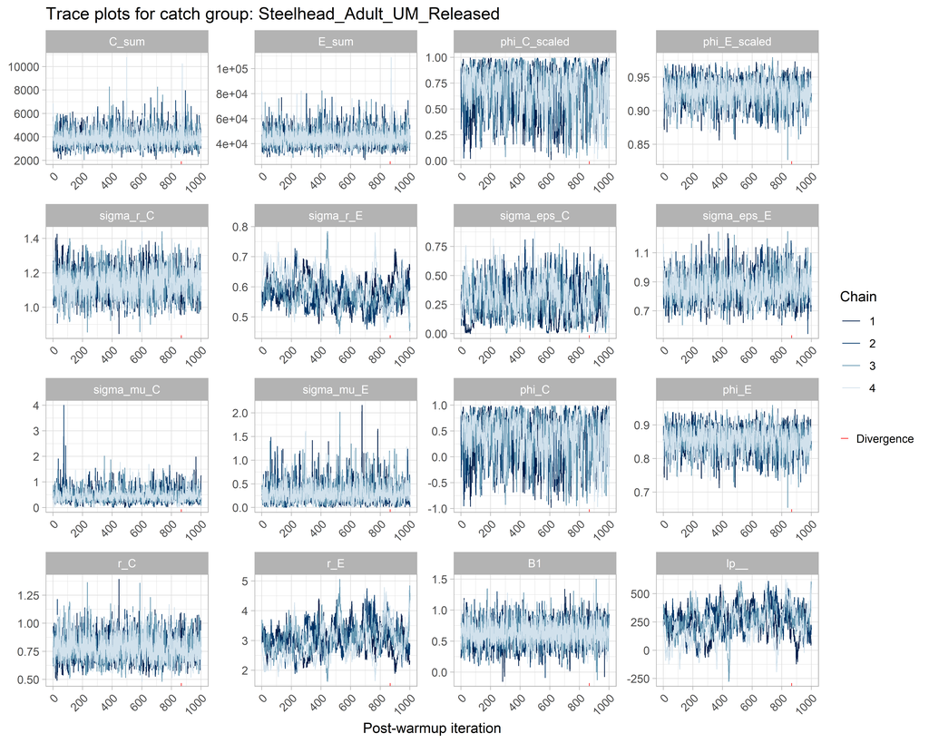

```r
# Plot and save traceplots
purrr::iwalk(diagnostics_bss, function(diag, ecg) {
  # Print to document
  print(diag$traceplots)

  # Save to figures folder
  # save_plot(
  #   diag$traceplots,
  #   paste0("traceplots_", ecg, ".png"),
  #   width = 12,
  #   height = 10
  # )
})
```

### BSS estimates summary

```r
overview_combined <- purrr::imap_dfr(
  estimates_bss,
  ~ .x$overview |> mutate(catch_group = .y)
)

# Create a gt table with row groups
overview_combined |>
  gt(groupname_col = "catch_group") |>
  fmt_number(-c(estimate, est_cg, catch_group), decimals = 1) |>
  tab_style(
    style = cell_fill(),
    locations = cells_body(columns = "50%")
  ) |>
  tab_style(
    style = cell_fill(),
    locations = cells_body(columns = "50%")
  ) |>
    tab_header(title = "Total estimates of angler effort and catch for catch groups analyzed in this report. Statistics correspond to effort and catch estimates generated using a Bayesian state space creel model. Effort was estimated for each individual catch group model run.") |>
  tab_options(
    heading.title.font.size = px(14),
    table.font.color = "black"
  )
```

Total estimates of angler effort and catch for catch groups analyzed in this report. Statistics correspond to effort and catch estimates generated using a Bayesian state space creel model. Effort was estimated for each individual catch group model run.

| estimate | est_cg | mean | se_mean | sd | 2.5% | 25% | 50% | 75% | 97.5% | n_eff | Rhat | n_div |
| --- | --- | --- | --- | --- | --- | --- | --- | --- | --- | --- | --- | --- |
| Steelhead_Adult_UM_Released |  |  |  |  |  |  |  |  |  |  |  |  |
| E_sum | Steelhead_Adult_UM_Released | 44,631.4 | 107.1 | 6,941.2 | 33,770.8 | 39,917.4 | 43,626.9 | 48,312.4 | 60,724.9 | 4,203.7 | 1.0 | 1.0 |
| C_sum | Steelhead_Adult_UM_Released | 3,886.9 | 11.9 | 729.6 | 2,760.0 | 3,387.0 | 3,785.0 | 4,277.2 | 5,585.2 | 3,771.5 | 1.0 | 1.0 |

#### Posterior Probability Density Plots

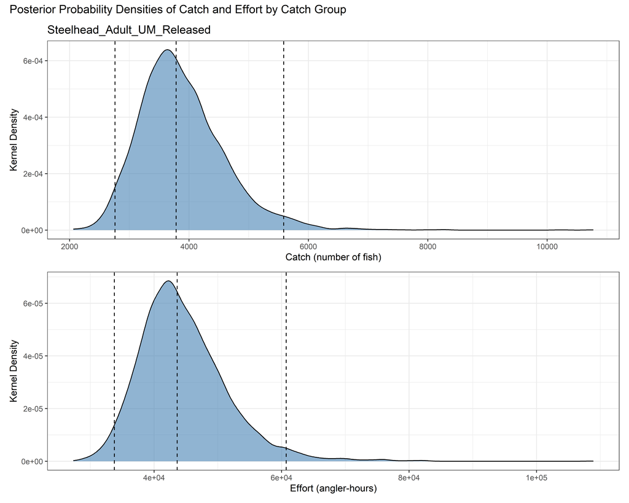

Posterior probability density plots showing the distribution of estimated catch (number of fish) and effort (angler-hours) for estimated catch groups. Each panel displays a kernel density curve representing the relative likelihood of different parameter values from the Bayesian creel model’s posterior distribution. The x-axis shows the estimated quantity (either number of fish caught or angler-hours expended). The y-axis shows the probability density for parameter estimates— higher values indicate parameter values that are more supported by the data and model. The shaded area under each curve represents the full range of plausible values. Vertical dashed lines mark the 2.5th percentile (lower credible limit), 50th percentile (median), and 97.5th percentile (upper credible limit), which together define the 95% credible interval—the range within which the true parameter value lies with 95% probability given the data and model assumptions. Effort was estimated for each individual catch group model run.

```r
# Extract density plots from estimates_bss list
plots_list <- map(estimates_bss, "density_plot") |>
  compact()  # Remove any NULL plots

# Combine all plots vertically
combined_figure <- wrap_plots(plots_list, ncol = 1) +
  plot_annotation(
    title = "Posterior Probability Densities of Catch and Effort by Catch Group"
  ) &
  theme(strip.text = element_text(size = 10))

# Print to document
print(combined_figure)
```

```r
# Save explicitly
save_plot(
  combined_figure,
  "posterior_probability_densities.png",
  width = 10,
  height = 12
)
```

#### plot daily catch BSS

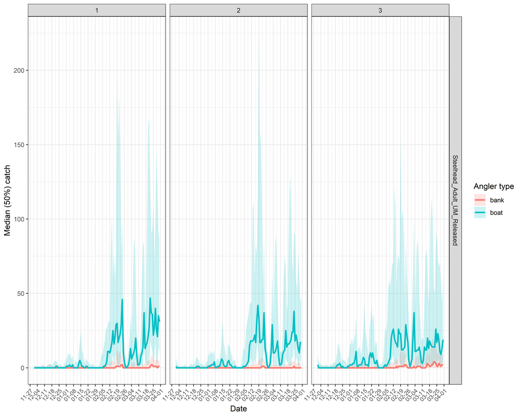

```r
plot_bss_catch_daily <-
  map_df(estimates_bss, ~.x$catch_daily) |>
    ggplot(aes(x = event_date, y = `50%`, fill = angler_final, color = angler_final)) +
    geom_ribbon(aes(ymin = `2.5%`, ymax = `97.5%`), alpha = 0.2, color = "transparent") +
    geom_line(lwd = 1) +
    ylab("Median (50%) catch") +
    xlab("Date") +
    labs(color = "Angler type", fill = "Angler type") +
    scale_x_date(date_breaks = "1 week", date_labels = "%m-%d") +
    theme_bw() +
    theme(axis.text.x = element_text(angle = 45, hjust = 1, size = 8)) +
    facet_grid(est_cg ~ section_num, scales = "free_y")

# Print with specific dimensions
print(plot_bss_catch_daily)
```

```r
# Save with larger dimensions
save_plot(
  plot_bss_catch_daily,
  "bss_catch_daily.png",
  width = 12,
  height = 4 + (2 * n_distinct(map_df(estimates_bss, ~.x$catch_daily)$est_cg))
)
```

#### plot daily effort BSS

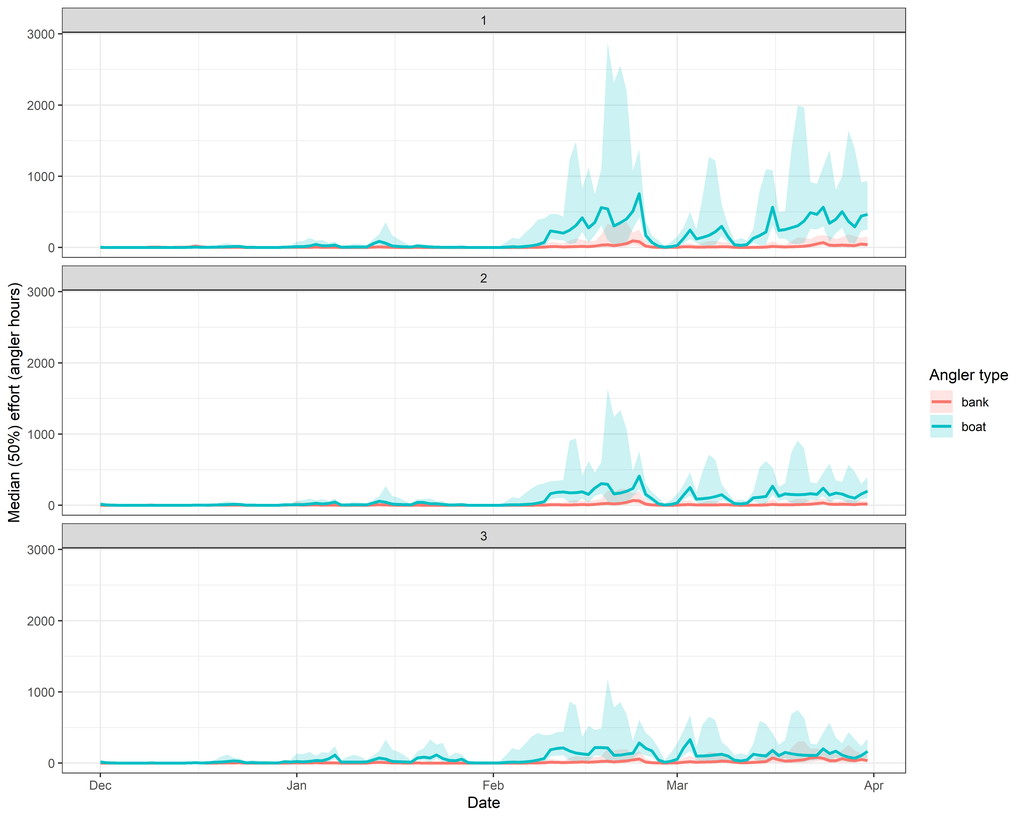

```r
plot_bss_effort_daily <-
  estimates_bss[[1]]$effort_daily |>
    ggplot(aes(x = event_date, y = `50%`, fill = angler_final, color = angler_final)) +
    geom_ribbon(aes(ymin = `2.5%`, ymax = `97.5%`), alpha = 0.2, color = "transparent") +
    geom_line(lwd = 1) +
    ylab("Median (50%) effort (angler hours)") +
    xlab("Date") +
    labs(color = "Angler type", fill = "Angler type") +
    scale_x_date() +
    theme_bw() +
    facet_wrap(~section_num, nrow = estimates_bss[[1]]$effort_daily$section_num |> n_distinct())

# Print to document
print(plot_bss_effort_daily)
```

```r
# Save explicitly
save_plot(
  plot_bss_effort_daily,
  "bss_effort_daily.png",
  width = 12,
  height = 8
)
```